# Nube de polvo en Sevilla (Febrero 2016)

Francisco Rodriguez-Sanchez

2016-02-24

Entre los días 20 y 22 de Febrero de 2016 ha habido una nube de polvo sahariano sobre la Península, que se ha dejado notar también en Sevilla (http://www.abc.es/sociedad/abci-medio-ambiente-nube-polvo-sahariano-dispara-contaminacion-aire-particulas-toda-peninsula-201602231715_noticia.html).

Vamos a utilizar nuestro paquete [`aire`](https://github.com/SevillaR/aire) para analizar la calidad del aire (más concretamente la concentración de partículas) en la última semana.

Primero cargamos el paquete:

```r
library(aire)
```

Ahora descargamos los datos de la última semana para la provincia de Sevilla:

```r
datos <- get_daily_data(province = "se", from = "2016-02-15", to = "2016-02-23")
```

Y los analizamos con el paquete `openair`:

```r
library(openair)
```

Con la función `summaryPlot` podemos inspeccionar los datos:

```
##   Provincia   Municipio        site   Direccion       date1       date2
## "character" "character"    "factor" "character"   "POSIXct"    "POSIXt"
##         SO2        PART         NO2          CO          O3         SH2
##   "integer"   "integer"   "integer"   "integer"   "integer"   "logical"
```

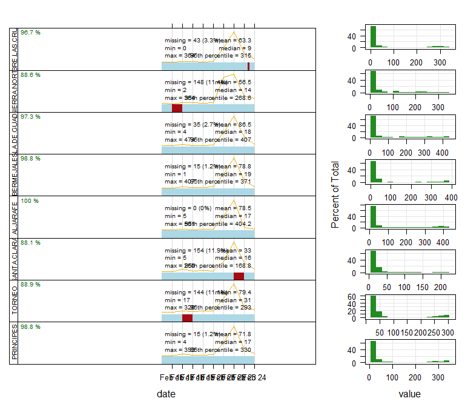

```r
summaryPlot(datos, pollutant = "PART", period = "months")
```

La función `timePlot` nos dibuja la serie temporal para cada estación más claramente:

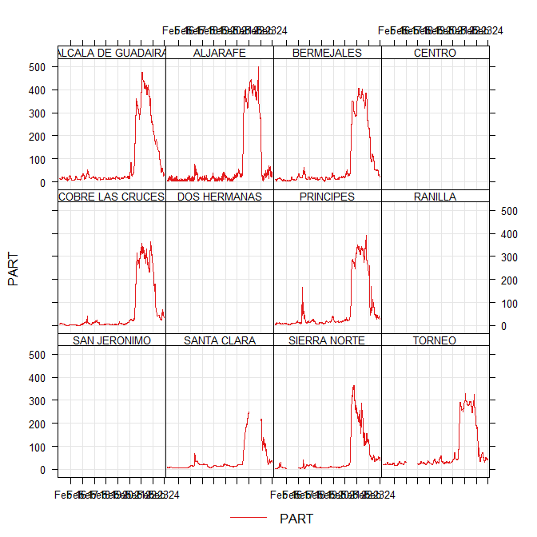

```r
timePlot(datos, pollutant = "PART", type = "site")
```

Vemos que el pico de contaminación por partículas se produjo entre el 20 y 22 de Febrero, y que se alcanzaron valores de **hasta 500 microgramos por metro cúbico** de aire, cuando los valores normales están por debajo de 25 microgramos (http://bit.ly/airedata).

También podemos hacer un `calendarPlot`:

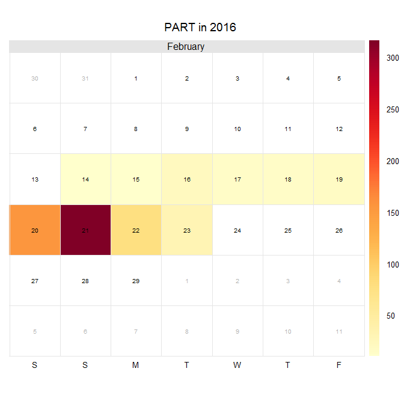

```r
calendarPlot(datos, pollutant = "PART")
```

Finalmente hacemos un mapa de la concentración de partículas por estaciones para el día de mayor contaminación (21 de Febrero).

Primero descargamos y preparamos los datos:

```r
datos.21 <- get_daily_data("2016-02-21", "se")
data(stations)
datos.21.sp <- merge(datos.21, stations[, "site"], by = "site", all.x = TRUE)
```

Y luego hacemos el mapa:

[figure not shown]

```r
GoogleMapsPlot(datos.21.sp, pollutant = "PART")
```

Se puede observar que aunque la densidad de partículas fue muy alta en toda la zona, hubo estaciones (como la de la Sierra Norte) con valores algo mejores.